# Main Function Usage

Allen Li

November 25, 2019

## met_hastings() tutorial

The main function takes in many inputs, which may be confusing at first, so by breaking it down,  
1. nsims - how many trials you need  
2. start - initial estimate  
3. burn_in how many trials to throw away, default = 0  
4. the jumping distribution and its parameters  
5. the sampling distribution and its parameters  
5.5. a function containing your likelihood of your sampling distribution

A simple example is given as follows:  
Where we are jumping from N$(\theta,2)$ and sampling from $\gamma(\alpha = 1.7, \beta = 4.4)$

```r
draws_1 <- met_hastings(nsims = 10000, start = 1, burn_in = 1000, jump = "normal",
jparams = 2,distr = "gamma",c(1.7,4.4))

tail(draws_1)
```

```
## [1] 0.4050593 0.5669523 0.5669523 0.5669523 0.5809327 0.5809327
```

```r
bayes_CI(draws_1,0.1)
```

```
##         5%        95%
## 0.05355388 0.98545705
```

To demonstrate the usefulness of the Metropolis-Hastings algorithmn, an example with a sampling distribution that is hard to sample from is presented as follows, where we are sampling from a mixed gaussian distribution:

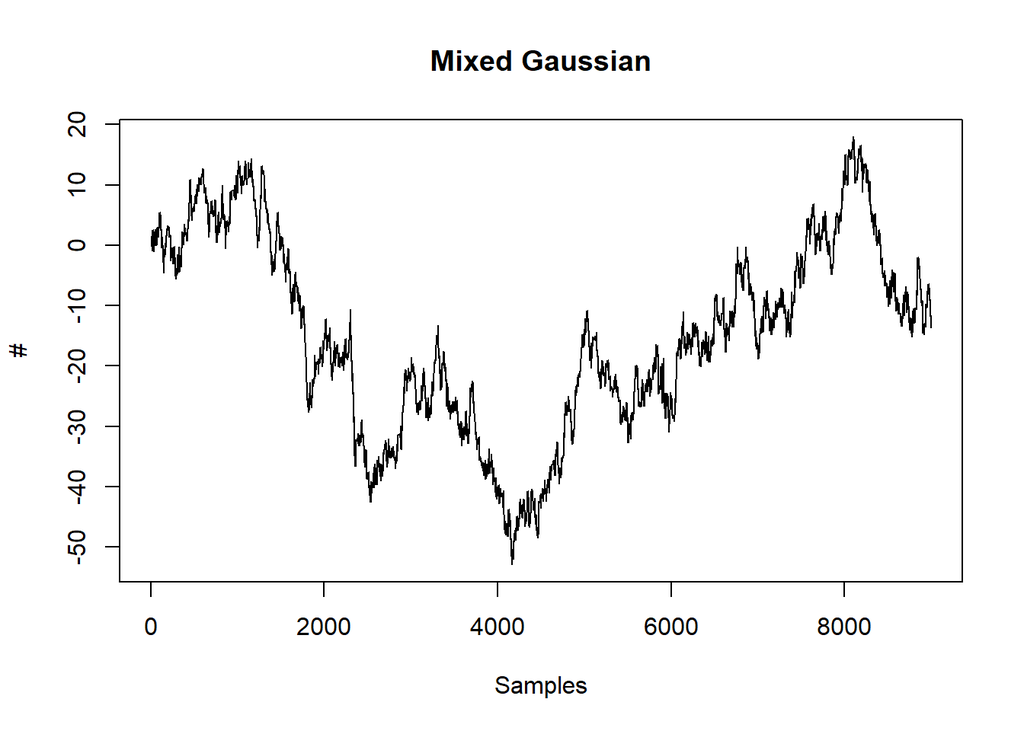

```r
nn_lk <- function(tstar,params) {
 lkld <- 0.5*rnorm(1,tstar,params[1]) + 0.5*rnorm(1,0,params[2])
}
draws_3 <- met_hastings(nsims = 10000, start = 1, burn_in = 1000,
distr = "custom", dparams = c(1,100) , likelihood = nn_lk)

plot(draws_3, type = "l",main = "Mixed Gaussian", xlab = "Samples", ylab = "#")
```

```r
system.time(met_hastings(nsims = 100000, start = 1, burn_in = 2500,
                          distr = "custom", dparams = c(1,100) , likelihood = nn_lk))
```

```
##    user  system elapsed
##    3.80    0.05    5.18
```